# Practical Machine Learning Project

Ayush Kumar

October 20, 2018

The goal of your project is to predict the manner in which they did the exercise. This is the “classe” variable in the training set. You may use any of the other variables to predict with. You should create a report describing how you built your model, how you used cross-validation, what you think the expected out of sample error is, and why you made the choices you did. You will also use your prediction model to predict 20 different test cases.

Loading some useful libraries

```r
library(caret)
```

```r
library(rpart)
library(rpart.plot)
library(rattle)
library(e1071)
library(randomForest)
library(RColorBrewer)
```

Downloading data

```r
TrainingData <- read.csv(url("https://d396qusza40orc.cloudfront.net/predmachlearn/pml-training.csv"),header=TRUE)
dim(TrainingData)
```

```
## [1] 19622   160
```

```r
str(TrainingData)
```

[output not shown]

[output cut: 86 more lines]

```r
TestData <- read.csv(url("https://d396qusza40orc.cloudfront.net/predmachlearn/pml-testing.csv"),header=TRUE)
dim(TestData)
```

```
## [1]  20 160
```

Here, we can see that some variable have most of the values as NA they will not create any effect to the model so better delete them also some columns are not using that should be deleted so, now i am going to clean the data

# Data Cleaning

```r
# we select the coulumn having NA values more than the 90%
delete <- which(colSums(is.na(TrainingData) |TrainingData=="")>0.9*dim(TrainingData)[1])
Newtraining<-TrainingData[,-delete]
#checking varience if they are near zero
nearZeroVar(Newtraining,saveMetrics = T)
```

```
##                      freqRatio percentUnique zeroVar   nzv
## X                     1.000000  100.00000000   FALSE FALSE
## user_name             1.100679    0.03057792   FALSE FALSE
## raw_timestamp_part_1  1.000000    4.26562022   FALSE FALSE
## raw_timestamp_part_2  1.000000   85.53154622   FALSE FALSE
## cvtd_timestamp        1.000668    0.10192641   FALSE FALSE
## new_window           47.330049    0.01019264   FALSE  TRUE
## num_window            1.000000    4.37264295   FALSE FALSE
## roll_belt             1.101904    6.77810621   FALSE FALSE
## pitch_belt            1.036082    9.37722964   FALSE FALSE
## yaw_belt              1.058480    9.97349913   FALSE FALSE
## total_accel_belt      1.063160    0.14779329   FALSE FALSE
## gyros_belt_x          1.058651    0.71348486   FALSE FALSE
## gyros_belt_y          1.144000    0.35164611   FALSE FALSE
## gyros_belt_z          1.066214    0.86127816   FALSE FALSE
## accel_belt_x          1.055412    0.83579655   FALSE FALSE
## accel_belt_y          1.113725    0.72877383   FALSE FALSE
## accel_belt_z          1.078767    1.52379982   FALSE FALSE
## magnet_belt_x         1.090141    1.66649679   FALSE FALSE
## magnet_belt_y         1.099688    1.51870350   FALSE FALSE
## magnet_belt_z         1.006369    2.32901845   FALSE FALSE
## roll_arm             52.338462   13.52563449   FALSE FALSE
## pitch_arm            87.256410   15.73234125   FALSE FALSE
## yaw_arm              33.029126   14.65701763   FALSE FALSE
## total_accel_arm       1.024526    0.33635715   FALSE FALSE
## gyros_arm_x           1.015504    3.27693405   FALSE FALSE
## gyros_arm_y           1.454369    1.91621649   FALSE FALSE
## gyros_arm_z           1.110687    1.26388747   FALSE FALSE
## accel_arm_x           1.017341    3.95984099   FALSE FALSE
## accel_arm_y           1.140187    2.73672409   FALSE FALSE
## accel_arm_z           1.128000    4.03628580   FALSE FALSE
## magnet_arm_x          1.000000    6.82397309   FALSE FALSE
## magnet_arm_y          1.056818    4.44399144   FALSE FALSE
## magnet_arm_z          1.036364    6.44684538   FALSE FALSE
## roll_dumbbell         1.022388   84.20650290   FALSE FALSE
## pitch_dumbbell        2.277372   81.74498012   FALSE FALSE
## yaw_dumbbell          1.132231   83.48282540   FALSE FALSE
## total_accel_dumbbell  1.072634    0.21914178   FALSE FALSE
## gyros_dumbbell_x      1.003268    1.22821323   FALSE FALSE
## gyros_dumbbell_y      1.264957    1.41677709   FALSE FALSE
## gyros_dumbbell_z      1.060100    1.04984201   FALSE FALSE
## accel_dumbbell_x      1.018018    2.16593619   FALSE FALSE
## accel_dumbbell_y      1.053061    2.37488533   FALSE FALSE
## accel_dumbbell_z      1.133333    2.08949139   FALSE FALSE
## magnet_dumbbell_x     1.098266    5.74864948   FALSE FALSE
## magnet_dumbbell_y     1.197740    4.30129447   FALSE FALSE
## magnet_dumbbell_z     1.020833    3.44511263   FALSE FALSE
## roll_forearm         11.589286   11.08959331   FALSE FALSE
## pitch_forearm        65.983051   14.85577413   FALSE FALSE
## yaw_forearm          15.322835   10.14677403   FALSE FALSE
## total_accel_forearm   1.128928    0.35674243   FALSE FALSE
## gyros_forearm_x       1.059273    1.51870350   FALSE FALSE
## gyros_forearm_y       1.036554    3.77637346   FALSE FALSE
## gyros_forearm_z       1.122917    1.56457038   FALSE FALSE
## accel_forearm_x       1.126437    4.04647844   FALSE FALSE
## accel_forearm_y       1.059406    5.11160942   FALSE FALSE
## accel_forearm_z       1.006250    2.95586586   FALSE FALSE
## magnet_forearm_x      1.012346    7.76679238   FALSE FALSE
## magnet_forearm_y      1.246914    9.54031189   FALSE FALSE
## magnet_forearm_z      1.000000    8.57710733   FALSE FALSE
## classe                1.469581    0.02548160   FALSE FALSE
```

```r
# also deleting irrelevant columns
Newtraining<-Newtraining[,-c(1:7)]
# checking the new dimension
dim(Newtraining)
```

```
## [1] 19622    53
```

we should also do the same for the Test data

```r
# we select the coulumn having NA values more than the 90%
delete <- which(colSums(is.na(TestData) |TestData=="")>0.9*dim(TestData)[1])
Newtest<-TestData[,-delete]
# also deleting irrelivent coulumns
Newtest<-Newtest[,-c(1:7)]
# checking new dimension
dim(Newtest)
```

```
## [1] 20 53
```

Dividing the training data into test and train data

```r
set.seed(4444)
part <- createDataPartition(Newtraining$classe, p=0.75, list=FALSE)
train2 <- Newtraining[part,]
test2<- Newtraining[-part,]
dim(train2)
```

```
## [1] 14718    53
```

```r
dim(test2)
```

```
## [1] 4904   53
```

Now we have the cleaned data now we n apply the algorithms We will use here the tree classification as it is non-linear But we have to do cross-validation as to get more training data within the training data

### Using Class tree

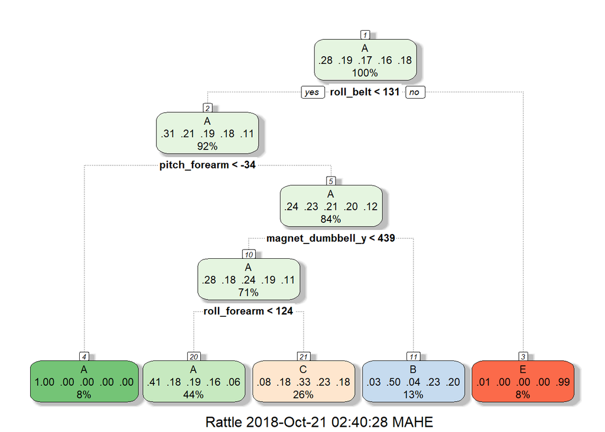

```r
crossV<-trainControl(method ="cv",number = 5)
treeModel<-train(classe~.,data=train2,method="rpart",trControl=crossV)
fancyRpartPlot(treeModel$finalModel)
```

Now, we will see the confusion matrix

```r
train3<- predict(treeModel,newdata=test2)

confusion1 <- confusionMatrix(test2$classe,train3)

confusion1$table
```

```
##           Reference
## Prediction    A    B    C    D    E
##          A 1260   24  108    0    3
##          B  378  339  232    0    0
##          C  382   25  448    0    0
##          D  379  138  287    0    0
##          E  136  111  249    0  405
```

```r
confusion1$overall[1]
```

```
## Accuracy
##      0.5
```

### Usig random forest method

```r
model_RF <- train(classe~., data=train2, method="rf", trControl=crossV, verbose=FALSE)
trainpred <- predict(model_RF,newdata=test2)

confMatRF <- confusionMatrix(test2$classe,trainpred)

# display confusion matrix and model accuracy
confMatRF$table
```

```
##           Reference
## Prediction    A    B    C    D    E
##          A 1394    0    0    0    1
##          B    3  944    2    0    0
##          C    0    3  852    0    0
##          D    0    0   16  788    0
##          E    0    0    0    3  898
```

```r
confMatRF$overall[1]
```

```
##  Accuracy
## 0.9942904
```

we,can say that Random forest is best so,we will use it as the predicton algorithm

```r
FinalTestPred <- predict(model_RF,newdata=TestData)
FinalTestPred
```

```
##  [1] B A B A A E D B A A B C B A E E A B B B
## Levels: A B C D E
```